# 4-GBIF

## GBIF Data

An idea on how to plot GBIF data. https://www.gbif.org/

This is a way to make your own range maps. There are several other ways to go about retrieving data from GBIF such as the “rgbif” R package.

“bdvis” provides downloading/mapping instructions that may work for you: https://doi.org/10.1093/bioinformatics/btw333

It didn’t work for me, so I downloaded the GBIF data myself.

## Watch out for….

- Coordinates: Does the entry have them?
- Sampling bias? Some places have more records than others…
- What is classified. Pleuronectidae for example contains a few other families on GBIF.
- How specific is the identification? To species? To genus?

Pleuronectiformes also creates a 357 Mb data file. Downloading via an API (with rgbif) is a bit cumbersome at that point.

## Starting data.

I have created a file for all Bothidae occurrence records with GBIF: https://doi.org/10.15468/dl.mpxaok

It is too large to synch well with GitHub… So, I made it smaller by only keeping a few key fields:

family genus species decimalLatitude decimalLongitude

This reduced file is in /4-GBIF/ folder and is named “bothidae.csv” and is ~ 3 Mb.

#### Side Note: How I reduced the file size with bash.

I found the GBIF file to be a problem to parse with all the fields as well making import in R pretty much impossible for me.

Here is how I reduced the file to columns 8,9,10,17, and 18 at the command line. This is not with R.

```bash
cat 0008756-181108115102211.csv | cut -f 8,9,10,17,18 > bothidae.csv
```

## Starting out

What does the data file look like? What do we want in the end to make a raster? You can open it with a text editor and take a look.

What we need to do do is import the data into R. Like last time, I made a tibble.

- I used the tidyverse library (and dplyr)
- To load the file, I used read.table
- It is important to consider missing entries in the table with GBIF data…
- I used as_tibble
- I used rename

Create a tibble like so:

```
## # A tibble: 63,314 x 5
##    Family   Genus Species Latitude Longitude
##    <fct>    <fct> <fct>      <dbl>     <dbl>
##  1 Bothidae ""    ""         -22.0      114.
##  2 Bothidae ""    ""         -22.0      114.
##  3 Bothidae ""    ""         -22.0      114.
##  4 Bothidae ""    ""         -22.0      114.
##  5 Bothidae ""    ""         -22.0      114.
##  6 Bothidae ""    ""         -22.0      114.
##  7 Bothidae ""    ""         -23.0      114.
##  8 Bothidae ""    ""         -23.0      114.
##  9 Bothidae ""    ""         -24.0      113.
## 10 Bothidae ""    ""         -23.0      113.
## # ... with 63,304 more rows
```

## What do we want again?

We would like to have an estimate of number of species within an a degree grid square (e.g. species in 1 deg Latitude by 1 deg Longitude). You may have noticed that we have entries just for Bothidae with no species. Let’s remove those.

- Use dplyr filter and a Boolean operator

```
## # A tibble: 56,488 x 5
##    Family   Genus          Species                    Latitude Longitude
##    <fct>    <fct>          <fct>                         <dbl>     <dbl>
##  1 Bothidae Bothus         Bothus mancus                -16.1     -146.
##  2 Bothidae Engyophrys     Engyophrys sanctilaurentii     7.57     -78.8
##  3 Bothidae Monolene       Monolene asaedae               7.74     -82.4
##  4 Bothidae Chascanopsetta Chascanopsetta lugubris       14.8      123.
##  5 Bothidae Chascanopsetta Chascanopsetta lugubris       16.2      115.
##  6 Bothidae Chascanopsetta Chascanopsetta lugubris      -22.9      167.
##  7 Bothidae Monolene       Monolene asaedae               9.51     -85.2
##  8 Bothidae Taeniopsetta   Taeniopsetta ocellata         20.8      117.
##  9 Bothidae Chascanopsetta Chascanopsetta lugubris       -5.72     154.
## 10 Bothidae Monolene       Monolene asaedae               9.51     -85.2
## # ... with 56,478 more rows
```

Should be ~7,000 less entries.

## How to get species diversity within a grid square…

### Creating an using a function in R.

Converting our point collections to species is complicated. I have made a function and stored it in an external file, rasterize.R. This is the basics of using a function in R.

The basic form of a function in R:

- Declare variables e.g. (x,y)
- Do something to variables (x*y)
- Return something else

```r
Multiply <- function(x,y) {
product<-x*y
return(product)
}
```

Here is how to use the function:

```r
Multiply(3,5)
```

```
## [1] 15
```

The function should show up in your Environment tab within RStudion.

### Rasterize

The Rasterize function I wrote can be loaded with source. Can you source it?

```r
source("rasterize.R")
```

Rasterize requires three things:

1. cellSize -> the grid square ofLongitude/Latidue as a number, e.g. 2
2. breaks -> A vector to combine species counts e.g. c(“10”, “20”, “30”)
3. dataFrame -> A data frame with Family, Genus, Species, Latitude, and Longitude columns.

Using it:

```r
cellSize<-3
breaks<-seq(0, length(levels(df$Species)), 5) # From 0 to 160 here by 10

raster<-Rasterize(cellSize, breaks, df)
raster
```

```
## # A tibble: 718 x 4
## # Groups:   Diversity, Breaks [24]
##    Diversity Longitude Latitude Breaks
##        <int>     <dbl>    <dbl> <fct>
##  1         1     -178.    -46.5 (0,5]
##  2         1     -178.    -43.5 (0,5]
##  3         2     -178.    -28.5 (0,5]
##  4        10     -178.    -19.5 (5,10]
##  5         8     -178.    -16.5 (5,10]
##  6         4     -178.    -13.5 (0,5]
##  7         1     -176.    -43.5 (0,5]
##  8         1     -176.    -22.5 (0,5]
##  9         1     -176.    -19.5 (0,5]
## 10         1     -176.    -13.5 (0,5]
## # ... with 708 more rows
```

## Plotting diversity within grid squares.

#### Plotting with “Diversity”:

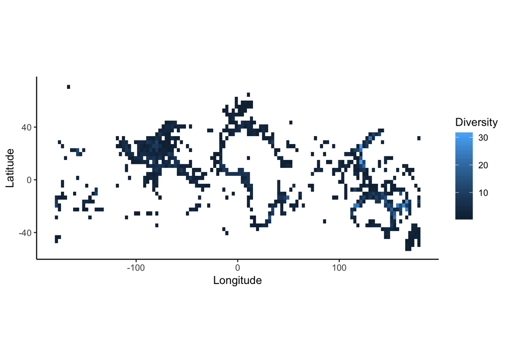

```r
ggplot()+geom_raster(data=raster, aes(x=Longitude,y=Latitude,
                                      fill=Diversity))+
  coord_fixed(1.3)+
  theme_classic()
```

- Can you use “scale_fill_continuous” to change the color scheme?

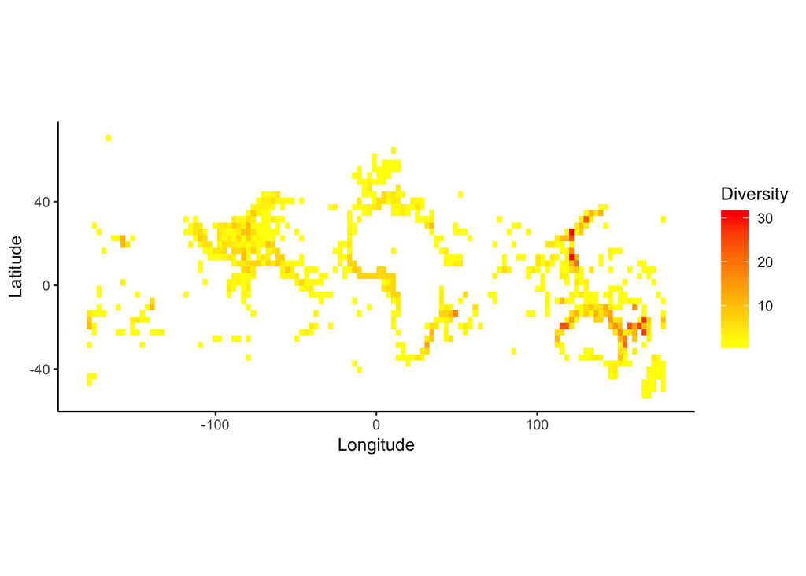

#### Plotting with “Breaks”

Plotting with “Breaks” requires us to set our own color scale. I used the “heat.colors” function.

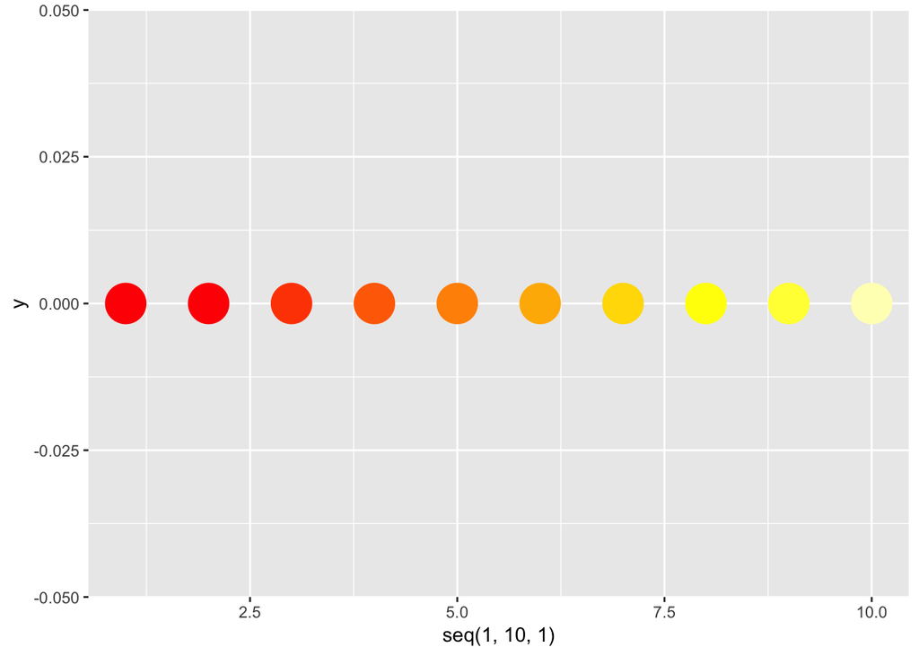

```r
heatColors<-heat.colors(10)

ggplot()+geom_point(aes(x=seq(1,10,1), y=0), cex=10, color=heatColors)
```

```r
number<-length(unique(raster$Breaks)) # Number of colors we need

colors<-rev(heat.colors(number)) #heat.colors produces the number of colors, with yellow high and red low, so I reversed it.
```

We can incldue this custom scale in ggplot with the following command:

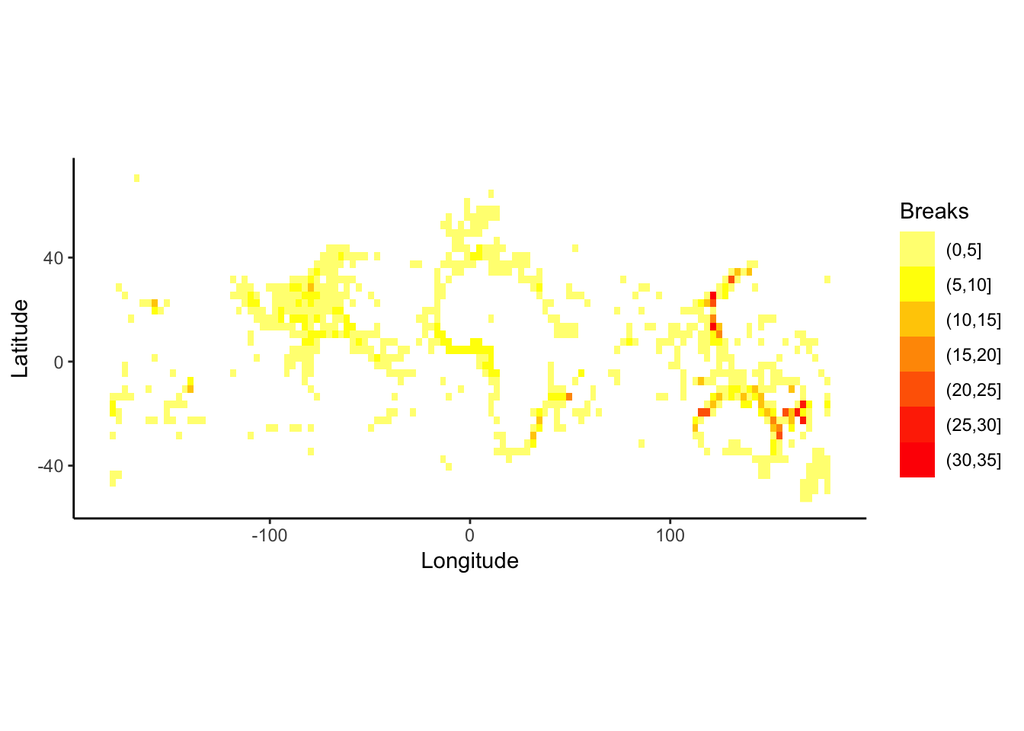

```r
scale_fill_manual(values=colors)
```

## What do you want to plot?

Why don’t you download your own taxon of interest and try to plot?

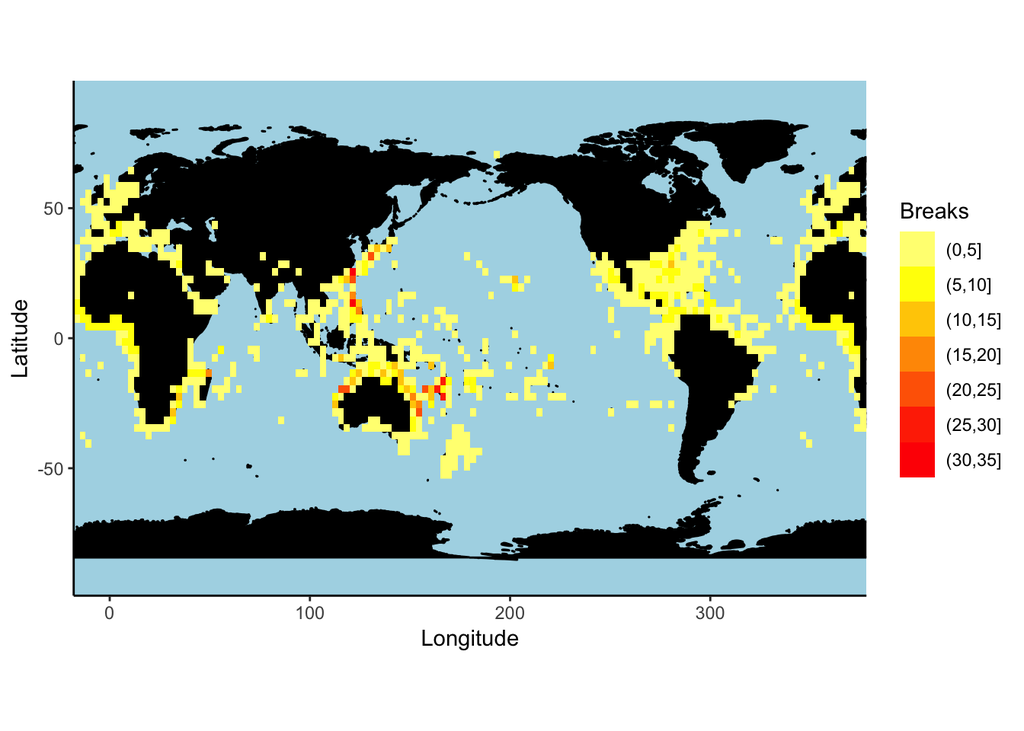